# Can Authoritarianism Curb the Spread of a Pandemic

Arnan Huang Summer 2021

## Background:

For centuries, the discussion of the role of government has been the center of political discourse, and yet despite the general liberalization of governments around the world, many authoritarian regimes still remain and retain broad support. Despite the general agreement, especially throughout the broadly liberalized western world, that a free and liberal government more often than not results in a happier population, it seems, at least in theory, that authoritarian governments do have some benefits.

With the appearance of COVID 19 and the resulting pandemic, the death and economic disaster left in its wake has revitalized the debate on whether authoritarian regimes may in fact dampen the effects of massive disasters such as a pandemic through more effective controls and regulations. Comparing the case numbers of an authoritarian regime such as China and that of the United States, one could hypothesize that perhaps only a strong authoritarian government would be able to mount an effective campaign against something such as a pandemic, where a liberal democracy would be unable to prevent the spread of a virus through limiting freedoms in such a way that an authoritarian government may have the institutional power to do.

## Data

Determining metrics for freedom and authoritarianism for countries is not as straightforward as population statistics, since there is no broadly accepted unit of democracy. How democratic a country is depends on a variety of factors including how their government is selected, how dissent is treated, or how much power the government holds to begin with.

#### How Can We Measure Democracy Quantitatively?

For this investigation, we will be using the Democracy Index compiled by the Economist Group. This takes into consideration how fair the national elections are as well as the overall power that civil servants have to implement policies. The biggest reason to use this metric rather than others developed by other groups is that the Democracy Index does not take into account economic living standards, as it would not allow us to isolate specifically the authoritarian nature of the government and any conclusion made off these other indices would require further investigation into how living standards may impact the spread of COVID 19. By isolating only the governmental factors, we can isolate economic variables as controls in order to make a more narrow statement specifically about the governmental response and effect on the spread of the virus. The Democracy Index for each country was obtained from The Economist.

We also want to further study the effect of a free press on the spread of COVID 19. While an authoritarian government may have more power to implement more powerful restrictions that could curb the spread of a pandemic, some have theorized that the limitations that authoritarian regimes place on the press may prevent the distribution of information which may impact the ability of individuals within the population to effectively take precautions to prevent the spread of the pandemic. One could hypothesize that this may increase the case numbers of authoritarian regimes, an opposite effect mentioned above. Because of this, we will isolate this variable by using the Free Press Index generated by Reporters Without Borders. This index uses a variety of indicators to generate a score that broadly scores how free the media is in a given company through surveys on a given country's media independence, censorship, transparency, and infrastructure.

Covid Data was imported from the world health organization. GDP data was imported from the World Bank.

### Why Use Cases Instead of Deaths?

The first decision we have to make is how we want to measure how effective a government is at curbing a pandemic. We can do this with cases or deaths. While deaths appears at first glance to be a better measurement of success as that is the ultimate goal of an effective pandemic response, to reduce deaths, the death rate as a result of a pandemic is much less correlated with government restrictions and rather how effective the healthcare system is in the country at reducing mortality from a given disease. What we are more interested in is whether authoritarian restrictions reduced the spread of a pandemic. We specifically used cases per capita as larger populations will obviously have more cases and we want to control for population.

### Where does GDP fit in?

IF we want to specifically isolate how government specifically impacts covid cases, we want to isolate certain variables that may create a false relationship between government and covid cases. GDP is one of them as wealthier countries tend to be more liberal and have more freedom. If having more resources means a government is more able to use these resources to prevent the spread of a panedmic, then we would find a negative relationship between democracic index and case number even if there was no causative link between these two variables.

We do not have an exhaustive list of all potential secondary variables, however, GDP covers many factors such as healthcare system, infrastructure, overall wealth, and a few other variables that would be directly related to pandemic containment, all of which should have a similar positive effect on pandemic containment which covers multiple secondary variables which should be sufficient for our purposes.

```python
pip install country_converter --upgrade
```

```python
import pandas as pd
import seaborn as sns
import numpy as np
import matplotlib.pyplot as plt
from scipy.stats import pearsonr
from scipy.stats import spearmanr
import country_converter as coco
```

### How Do We Merge Data?

We begin by importing COVID19 data from the WHO. Only a few of these columns will be relevant to our analysis, but we will remove these later. Here we encounter our first problem: Different resources sometimes use drastically different names for the same country. For example, in the WHO data, The Democratic People's Republic of Korea is listed with its full name, however, in the data from the Economist, they list the same country by its common name of North Korea. To solve this, we need to standardize all country names to the same name or in this case, code.

To do this, we have installed the package country_converter. This library contains a database of many different names of a country and allows us to conveert them into a standardized code, in this case, the ISO3 convention, using the CountryConverter method. This allows us to later merge the data without manually looking at non overlapping datasets and adding them back in. The method prints any country that it does not find a code for which will make it convenient for us to manually add them back if we have to.

We see five categories that do not have a country code. Global is not a country, it is the aggregation of all the data around the globe. This will not be useful since we are looking at governments and as of 2021 there is no world government. Bonaire, Sint Eustatius, and Saba are municipalities of the netherlands and thus will not have any democracy index. Other is obviously not a country so it can be ommitted.

```python
# Read data from csv file
covid_data = pd.read_csv("who_data.csv")
cc = coco.CountryConverter()
# Convert Country Name into standardixed ISO3 convention
covid_data['Name'] = cc.convert(names = covid_data['Name'], to = 'ISO3')
covid_data
```

```
Global not found in regex
Bonaire not found in regex
Other not found in regex
Sint Eustatius not found in regex
Saba not found in regex
```

|  | Name | WHO Region | Cases - cumulative total | Cases - cumulative total per 100000 population | Cases - newly reported in last 7 days | Cases - newly reported in last 7 days per 100000 population | Cases - newly reported in last 24 hours | Deaths - cumulative total | Deaths - cumulative total per 100000 population | Deaths - newly reported in last 7 days | Deaths - newly reported in last 7 days per 100000 population | Deaths - newly reported in last 24 hours | Transmission Classification |
| --- | --- | --- | --- | --- | --- | --- | --- | --- | --- | --- | --- | --- | --- |
| 0 | not found | NaN | 190770507 | 2447.48886 | 3420416 | 43.882203 | 408730 | 4095924 | 52.548628 | 56439 | 0.724084 | 6541 | NaN |
| 1 | USA | Americas | 33741532 | 10193.73000 | 189267 | 57.180000 | 6963 | 603880 | 182.440000 | 1682 | 0.510000 | 26 | Community transmission |
| 2 | IND | South-East Asia | 31144229 | 2256.82000 | 269853 | 19.550000 | 38164 | 414108 | 30.010000 | 5344 | 0.390000 | 499 | Clusters of cases |
| 3 | BRA | Americas | 19376574 | 9115.84000 | 286634 | 134.850000 | 34126 | 542214 | 255.090000 | 8726 | 4.110000 | 948 | Community transmission |
| 4 | RUS | Europe | 5982766 | 4099.63000 | 174293 | 119.430000 | 24633 | 149138 | 102.200000 | 5426 | 3.720000 | 719 | Clusters of cases |
| ... | ... | ... | ... | ... | ... | ... | ... | ... | ... | ... | ... | ... | ... |
| 233 | SHN | Africa | 0 | 0.00000 | 0 | 0.000000 | 0 | 0 | 0.000000 | 0 | 0.000000 | 0 | No cases |
| 234 | TKL | Western Pacific | 0 | 0.00000 | 0 | 0.000000 | 0 | 0 | 0.000000 | 0 | 0.000000 | 0 | No cases |
| 235 | TON | Western Pacific | 0 | 0.00000 | 0 | 0.000000 | 0 | 0 | 0.000000 | 0 | 0.000000 | 0 | No cases |
| 236 | TKM | Europe | 0 | 0.00000 | 0 | 0.000000 | 0 | 0 | 0.000000 | 0 | 0.000000 | 0 | No cases |
| 237 | TUV | Western Pacific | 0 | 0.00000 | 0 | 0.000000 | 0 | 0 | 0.000000 | 0 | 0.000000 | 0 | No cases |

238 rows × 13 columns

We pulled data for the democracy index from The Econonmist. Using the method above, we convert the country names to codes in order for simple cross comparisons and merging.

```python
# Read data from csv file
dem_data = pd.read_csv("dem_index.csv")
# isolate only data from 2020
dem_data = dem_data.loc[dem_data['year'] == 2020]
# Convert Country Name into standardixed ISO3 convention
dem_data['country'] = cc.convert(names = dem_data['country'], to = 'ISO3')
dem_data.sort_values('country')
```

|  | country | eiu | year |
| --- | --- | --- | --- |
| 975 | AFG | 2.85 | 2020 |
| 1599 | AGO | 3.66 | 2020 |
| 299 | ALB | 6.08 | 2020 |
| 1573 | ARE | 2.70 | 2020 |
| 663 | ARG | 6.95 | 2020 |
| ... | ... | ... | ... |
| 1326 | VNM | 2.94 | 2020 |
| 1586 | YEM | 1.95 | 2020 |
| 2093 | ZAF | 7.05 | 2020 |
| 2145 | ZMB | 4.86 | 2020 |
| 2158 | ZWE | 3.16 | 2020 |

167 rows × 3 columns

### Missing Data

Here we perform an inner merge. This omits any countries that each dataset does not agree on whether it is a country. If we include these, then certain places will be counted twice. For example, Saba is a dutch municipality that is counted separate in the WHO data. If we include this, we would be counting the netherlands twice in a way, and since the government is part of the netherlands anyway, it is already included with the democracy index.

That being said, if single values are NaN can still be represented if other data since only 2 data points are NaN. This should not affect the final analysis and we would only have to analyze it more closely if missing data was more common and had a patters, however, out of 167, the impact would be negligible on the final analysis.

```python
comb_data = covid_data.merge(dem_data, left_on='Name', right_on='country').sort_values('Name')[['Name','Cases - cumulative total per 100000 population', "Deaths - cumulative total per 100000 population",'eiu']]
comb_data.rename(columns = {'Cases - cumulative total per 100000 population':'cases', "Deaths - cumulative total per 100000 population":"deaths"}, inplace = True)
comb_data
```

|  | Name | cases | deaths | eiu |
| --- | --- | --- | --- | --- |
| 90 | AFG | 365.84 | 16.10 | 2.85 |
| 119 | AGO | 124.15 | 2.91 | 3.66 |
| 93 | ALB | 4610.67 | 85.34 | 6.08 |
| 39 | ARE | 6698.27 | 19.21 | 2.70 |
| 7 | ARG | 10523.94 | 224.69 | 6.95 |
| ... | ... | ... | ... | ... |
| 111 | VNM | 61.83 | 0.26 | 2.94 |
| 147 | YEM | 23.43 | 4.59 | 1.95 |
| 16 | ZAF | 3869.74 | 112.73 | 7.05 |
| 83 | ZMB | 1009.84 | 16.78 | 4.86 |
| 105 | ZWE | 562.60 | 17.64 | 3.16 |

165 rows × 4 columns

Since wealthy countries tend to be more democratic, we want to observe if wealth has a positive effect on the impact of covid on a country. This data was downloaded as a csv file from the World Bank. Country name was normalized as before to the ISO3 standard.

#### Why Use data from 2019?

Our goal is to see how GDP might impact covid, not the other way around. Many countries found their GDP growth decimated from the pandemic which peaked in 2020. Since the pandemic appeared in 2019, this would be the last year that would be relatively unaffected by GDP

```python
gdp = pd.read_csv('gdp.csv')
press = pd.read_csv('press.csv')
press = press[['EN_country', 'Score 2020']]
# Convert name of country to ISO3 Standard in same column
press['EN_country'] = cc.convert(names = press['EN_country'], to = 'ISO3')
gdp['Country or Area'] = cc.convert(names = gdp['Country or Area'], to = 'ISO3')
gdp
```

```
OECS not found in regex
United Republic of Tanzania: Zanzibar not found in regex
```

|  | Country or Area | Year | Item | Value |
| --- | --- | --- | --- | --- |
| 0 | AFG | 2019 | Gross Domestic Product (GDP) | 469.919090 |
| 1 | ALB | 2019 | Gross Domestic Product (GDP) | 5303.197823 |
| 2 | DZA | 2019 | Gross Domestic Product (GDP) | 3975.510381 |
| 3 | AND | 2019 | Gross Domestic Product (GDP) | 40887.421650 |
| 4 | AGO | 2019 | Gross Domestic Product (GDP) | 2670.850732 |
| ... | ... | ... | ... | ... |
| 207 | VEN | 2019 | Gross Domestic Product (GDP) | 4732.820093 |
| 208 | VNM | 2019 | Gross Domestic Product (GDP) | 2715.275874 |
| 209 | YEM | 2019 | Gross Domestic Product (GDP) | 855.066811 |
| 210 | ZMB | 2019 | Gross Domestic Product (GDP) | 1292.482076 |
| 211 | ZWE | 2019 | Gross Domestic Product (GDP) | 1463.985913 |

212 rows × 4 columns

```python
# Isolate Columns
gdp = gdp[['Country or Area', 'Value']]
# Merge by ISO3 Name
df = comb_data.merge(gdp, left_on='Name', right_on='Country or Area').sort_values('Name')
# Rename column to something more meaningful
df.rename(columns = {'Value':'gdp'}, inplace = True)
df
```

|  | Name | cases | deaths | eiu | Country or Area | gdp |
| --- | --- | --- | --- | --- | --- | --- |
| 0 | AFG | 365.84 | 16.10 | 2.85 | AFG | 469.919090 |
| 1 | AGO | 124.15 | 2.91 | 3.66 | AGO | 2670.850732 |
| 2 | ALB | 4610.67 | 85.34 | 6.08 | ALB | 5303.197823 |
| 3 | ARE | 6698.27 | 19.21 | 2.70 | ARE | 43103.323060 |
| 4 | ARG | 10523.94 | 224.69 | 6.95 | ARG | 10041.463300 |
| ... | ... | ... | ... | ... | ... | ... |
| 160 | VNM | 61.83 | 0.26 | 2.94 | VNM | 2715.275874 |
| 161 | YEM | 23.43 | 4.59 | 1.95 | YEM | 855.066811 |
| 162 | ZAF | 3869.74 | 112.73 | 7.05 | ZAF | 6001.389576 |
| 163 | ZMB | 1009.84 | 16.78 | 4.86 | ZMB | 1292.482076 |
| 164 | ZWE | 562.60 | 17.64 | 3.16 | ZWE | 1463.985913 |

165 rows × 6 columns

```python
# Read csv file
total_gdp = pd.read_csv("totalgdp.csv")
total_gdp = total_gdp[['Country Code', '2019']]
# Merge by ISO3 Name
df = df.merge(total_gdp, left_on = 'Name', right_on = 'Country Code')
# Rename column to something more meaningful
df.rename(columns = {'2019':'total_gdp'}, inplace = True)
```

Data for press freedom was obtained on rwb.org. (Reporters Without Borders). The same data cleaning and country conversion was performed on the data

```python
# Merge by ISO3 Name
df = df.merge(press, left_on = 'Name', right_on = 'EN_country')
# Rename column to something more meaningful
df.rename(columns = {'Score 2020':'press'}, inplace = True)
# Drop unnecessary columns
df = df.drop(['deaths', 'Country or Area', 'Country Code', 'EN_country'], axis = 1)
df
```

|  | Name | cases | eiu | gdp | total_gdp | press |
| --- | --- | --- | --- | --- | --- | --- |
| 0 | AFG | 365.84 | 2.85 | 469.919090 | 1.929110e+10 | 40.19 |
| 1 | AGO | 124.15 | 3.66 | 2670.850732 | 8.941719e+10 | 34.06 |
| 2 | ALB | 4610.67 | 6.08 | 5303.197823 | 1.528661e+10 | 30.59 |
| 3 | ARE | 6698.27 | 2.70 | 43103.323060 | 4.211420e+11 | 43.13 |
| 4 | ARG | 10523.94 | 6.95 | 10041.463300 | 4.454450e+11 | 28.99 |
| ... | ... | ... | ... | ... | ... | ... |
| 161 | VNM | 61.83 | 2.94 | 2715.275874 | 2.619210e+11 | 78.46 |
| 162 | YEM | 23.43 | 1.95 | 855.066811 | NaN | 62.35 |
| 163 | ZAF | 3869.74 | 7.05 | 6001.389576 | 3.514320e+11 | 21.59 |
| 164 | ZMB | 1009.84 | 4.86 | 1292.482076 | 2.330869e+10 | 38.21 |
| 165 | ZWE | 562.60 | 3.16 | 1463.985913 | 1.693243e+10 | 43.12 |

166 rows × 6 columns

## Exploratory Data Analysis

Our aim here is to take a glance at our data to find some broad patterns to form hypotheses from. By looking at each variable and its relation to case numbers, we should be able to visually confirm whether certain variables are correlated with each other, and then we can confirm these hypotheses using hypothesis testing later.

### Variable 1: EIU

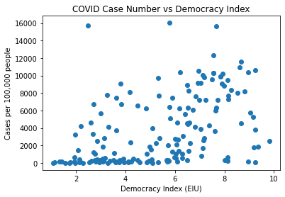

```python
plt.scatter(df.eiu, df.cases)
plt.title('COVID Case Number vs Democracy Index')
plt.xlabel('Democracy Index (EIU)')
plt.ylabel('Cases per 100,000 people')
plt.show()
```

### Variable 2: GDP per capita

An important thing to consider when studying relationships is that correlation is not equivalent to causation. Two variables that appear to be correlated may have underlying variables that influence both and in reality do not affect each other at all. When studying whether authoritarianism may lead to more or less cases, we should isolate as many control variables as possible and at least study whether they may have a relationship with any variables we are studying. One of these variables is a country's wealth which is often measured by GDP per capita. Wealthier countries tend to be more democratic as we see from the chart below, and because of this, we should study whether a wealth of a country also has a correlation to the number of covid cases. Wealthier countries have more resources to implement restrictions and provide incentives for contagion containment which is something we want to remove.

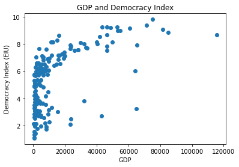

```python
plt.scatter(df.gdp, df.eiu)
plt.title('GDP and Democracy Index')
plt.xlabel('GDP')
plt.ylabel('Democracy Index (EIU)')
plt.show()
```

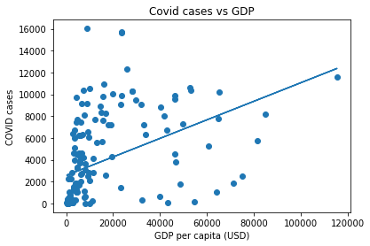

```python
plt.scatter(df.gdp, df.cases)
plt.title('Covid cases vs GDP')
plt.xlabel('GDP per capita (USD)')
plt.ylabel('COVID cases')
m, b = np.polyfit(df.gdp, df.cases, 1)
plt.plot(df.gdp, m*df.gdp + b)

plt.show()
```

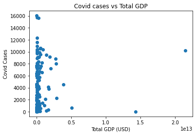

```python
df = df.dropna()

plt.scatter(df.total_gdp, df.cases)
plt.title('Covid cases vs Total GDP')
plt.xlabel('Total GDP (USD)')
plt.ylabel('Covid Cases')


plt.show()
```

This chart shows total GDP vs covid case numbers. This chart is less surprising as total GDP is not an incredibly useful metric since there are impoverished countries with high GDPs and extremely wealthy countries in terms of income per citizen with relatively low GDPs. Using GDP per capita is a better metric to measure the wealth of a country for this reason.

### Variable 3: Press Freedom and COVID Cases

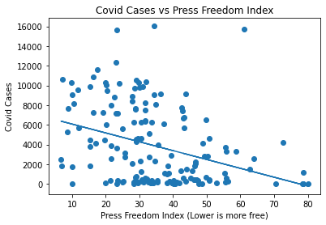

```
8.396652938177439e-06
-0.34304784274035977
```

```python
plt.scatter(df.press, df.cases)
plt.title('Covid Cases vs Press Freedom Index')
plt.xlabel('Press Freedom Index (Lower is more free)')
plt.ylabel('Covid Cases')

m, b = np.polyfit(df.press, df.cases, 1)
plt.plot(df.press, m*df.press + b)

plt.show()
stat, p = pearsonr(df.press, df.cases)
print(p)
print(stat)

plt.show()
```

We see another surprising result here. There appears to be a moderate to weak negative correlation between the press freedom index and the number of covid cases. A higher index means a less free press so it appears that countries with a freer press seem to have more COVID cases. Again we see countries with more freedom seem to have a higher variation of covid cases compared to countries with fairly restricted freedoms/high authoritarian scores.

## Hypothesis Testing:

Our visual observation of patterns is not enough to constitute evidence that certain variables are correlated. To quantify the relationship between these two variables, we will be using a spear correlation. This method measures the correlation between two variables without assuming linear dependence, rather than the pearson method which requires this assumption. This method generates a p value that represents the chance that the null hypothesis is true, which is that the two sets of data are completely uncorrelated or in other words, have a true correlation coefficient of 0.

The spearman test also returns a correlation coefficient which we can square to get explained variance, or how much of the variation in the data can be explained by the other variable. For example, if we plot COVID cases vs the price of gas and found an explained variance of 0.5, this would mean that 50% of the variance in covid cases could be explained by the price of gas.

### Democracy Index and Covid cases

Previously we saw a moderate correlation between the democracy index and COVID cases. We test this using the previously described spearman method which returns a correlation coefficient and p value. Additionally, using polyfit, we can fit the data to a linear regression plot and determine on average how many cases rise

- Null Hypothesis: There is no relationship between the cumulative case number per capita of a country and their democracy index
- Alternative Hypothesis: There is a positive relationship between the case number per capita and democracy index of a country
- alpha: 0.05

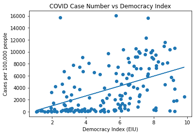

```
p = 2.1780313710652566e-14
explained variance = 0.3017167439064773
Increase in Cases per unit EIU: 825.7301707191169
```

```python
plt.scatter(comb_data.eiu, comb_data.cases)
plt.title('COVID Case Number vs Democracy Index')
plt.xlabel('Democracy Index (EIU)')
plt.ylabel('Cases per 100,000 people')
m, b = np.polyfit(comb_data.eiu, comb_data.cases, 1)
plt.plot(comb_data.eiu, m*comb_data.eiu + b)

stat, p = spearmanr(comb_data.eiu, comb_data.cases)

plt.show()
print('p = ' + str(p))
print('explained variance = ' + str(stat**2))
print('Increase in Cases per unit EIU: ' + str(m))
```

Since the p value is less than our alpha of 0.05, we reject the null hypothesis that there is no relationship between case number per capita and democracy index of a country and conclude some relationship exists between the two.

### GDP and COVID Cases

- null Hypothesis: GDP is not related to Case Numbers
- Alternative Hypothesis: GDP has a positive correlation with Case Numbers
- alpha : 0.05

[figure not shown]

```
1.5694255181608506e-08
0.42735173967463824
Increase in Cases per GDP per capita: 0.08247536226117287
```

```python
plt.scatter(df.gdp, df.cases)
plt.title('Covid cases vs Total GDP')
plt.xlabel('Total GDP (USD)')
plt.ylabel('Covid Cases')
m, b = np.polyfit(df.gdp, df.cases, 1)
plt.plot(df.gdp, m*df.gdp + b)

plt.show()
stat, p = pearsonr(df.gdp, df.cases)
print(p)
print(stat)
print('Increase in Cases per GDP per capita: ' + str(m))
```

Since the p value is less than our alpha of 0.05, we reject the null hypothesis that there is no relationship between case number per capita and GDP per capita of a country and conclude some relationship exists between the two.

[output not shown]

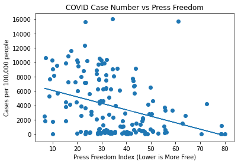

```
p = 1.6405033943921447e-06
explained variance = 0.134935948104606
Increase in Cases per Increase in Press Freedom Index: -89.88007935662408
```

```python
plt.scatter(df.press, df.cases)
plt.title('COVID Case Number vs Press Freedom')
plt.xlabel('Press Freedom Index (Lower is More Free)')
plt.ylabel('Cases per 100,000 people')
m, b = np.polyfit(df.press, df.cases, 1)
plt.plot(df.press, m*df.press + b)

stat, p = spearmanr(df.press, df.cases)

plt.show()
print('p = ' + str(p))
print('explained variance = ' + str(stat**2))
print('Increase in Cases per Increase in Press Freedom Index: ' + str(m))
```

Since the p value is less than our alpha of 0.05, we reject the null hypothesis that there is no relationship between case number per capita and the freedom of press in a given country and conclude some relationship exists between the two.

## Discussion

Overall we found a moderate positive correlation between COVID case number and the democracy index, or in other words, the more democratic a country was, the higher case numbers tended to be. This matches our initial hypothesis, and our anecdotal intuition when looking at how authoritarian countries such as China implemented massive restrictions which resulted in vastly reduced cases. We also found a surprising positive relation between GDP and case number which is bizzarre as having more money should not mean that there are more cases. One explanation for this could be the fact that GDP is a proxy for democracy index since liberal countries tend to be more wealthy. The positive correlation found between COVID case number and democracy index would then be represented in the positive correlation between GDP and case numbers. A more thorough study should be performed to isolate individual variables instead of using GDP as a proxy for multiple more directly related variables such as number of hospital beds or healthcare capacity or population density. For every increase in EIU, we found an average of 825 more cases per unit.

### Limitations:

All data analysis done here is under the assumption that reported COVID figures are current and accurate. This is not necessarily the case. It is entirely possible that authoritarian countries tend to also under report cases which would also explaint the variance found in this study. Further studies could study excess mortality rather than the self reported covid cases which may more accurately reflect COVID cases if countries inaccurately report data, however, that would also introduce extraneous variables since not all excess mortality could be explained by COVID directly such as other medical deaths unrelated to COVID that result from an overwhelmed healthcare system.

Ideally, future studies should perform a more comprehensive study by using multiple democracy indices developed by different organizations, as well as many more controls that are already well known to impact case number in a country. Instead of overall case number, cases after 60 days after the first case within a country could be studied instead since not all countries have had the same time to react to COVID. If the first case in one country was six months later than another country, this could drastically reduce their perceived covid cases even if they have the same exact response.

## Resources:

- Merging Data would have been extremely difficult without the country converter library. It is registered at PyPI under the name country_converter. [Country Converter](https://github.com/konstantinstadler/country_converter)
- SciKit Learn is another way to plot regression and predictions and allows for more complex machine learning. A useful extension of this project may be to see if a model could be trained to predict covid deaths from a variety of country metrics. Learn more at [SciKit Learn](https://scikit-learn.org/stable/user_guide.html)
- Pandas is an extremely flexible library to perform all sorts of data manipulation, especially using their dataframe object which allows for incredible flexbility. Learn more about what you can do with it at: [Pandas](https://pandas.pydata.org/docs/user_guide/index.html#user-guide)
- Scipy provides a vast library of stats functions under [Scipy.stats](https://docs.scipy.org/doc/scipy/reference/stats.html). Here you can learn about the differences between different regression models and the differences between them including assumptions and types of data.

## Data:

- [WHO COVID data](https://covid19.who.int/info/)
- [World Bank GDP data](https://data.worldbank.org/indicator/NY.GDP.PCAP.CD?locations=ZW)
- [RWB Press Freedom Index data](https://rsf.org/en/ranking_table)
- [Democracy Index Data](https://www.eiu.com/n/campaigns/democracy-index-2020/)
- Raw Data (Democracy Index)
- Raw Data (GDP per capita)
- Raw Data (Total GDP)
- Raw Data (COVID data)
- Raw Data (Press Freedom Index)